# Review for Final

FINA 3000 · Business Finance I · Class 26

Dr. Justin Mohr

November 19, 2026

## Final Exam

- **38 multiple choice**, no free response
- **120 minutes**
- A formula sheet is provided with the exam

Covers **Chapters 5, 7, 8, 9, 10, 11 and 12**.

Bring:

- Your **student ID**
- **Pencils**
- Your **BA II Plus**. No other calculator.

## Electronics on exam day

**Bags go on the wall.**

- During an exam, the only electronics allowed on your person are your calculator and any device you have a specific accommodation for from SDS.
- All other electronics must be silenced and left in your bag at the side of the room.
- This includes but is not limited to headphones, smart glasses, smart watches, smart rings, and regular watches.
- Unless specifically exempted, anything with the ability to control the flow of electrons other than a BA II plus is not allowed.

**If you have an SDS accommodation, talk to me. That is the exemption.**

## Menu

You pick what we work.

## Chapter 1: Introduction

All chapters

## Comparison of the forms of business

Comparison of the forms of business

|  | Sole proprietorship | Partnership | Corporation |
| --- | --- | --- | --- |
| Business owner | Single owner | Partners | Shareholders |
| Owner’s liability | Unlimited | Unlimited | **Limited** |
| Easy access to capital market? | No | No | **Yes** |
| Is management and ownership separate? | No | No | **Yes** |
| Are business owners exposed to double taxation? | No | No | **Yes** |

Chapter 1 topics

## Manager vs. Shareholders

What could be the problem here?

Their best interest could not be that of the firm!

Chapter 1 topics

## Manager vs. Shareholders cont.

- What could be the problem here?
  - Managers best interest is not that of the firm!
- How can I keep my manager working?
  - Managerial compensation packages
  - Direct intervention by shareholders
  - The threat of firing
  - The threat of takeover
- Inherent timing problem
  - I can’t reward based on the future, so packages are based in the present
  - Manipulation

Chapter 1 topics

## Management’s Goal

Management’s goal should be to take actions designed to maximize the firm’s intrinsic value, not its current market price.

Chapter 1 topics

## Intrinsic Value

[figure not shown]

Chapter 1 topics

## Chapters 3 and 4: Statements and Ratios

All chapters

## Ratios we learned today

- Current=Current Assets/Current Liabilities
  - How much are current liabilities covered by current assets
- Quick= $\frac{\text{Current Assets} - \text{Inventory}}{\text{Current Liabilities}}$
  - Inventories are least liquid
- Inventory Turnover= COGS/Inventory
  - How many times stock is sold through
- DSO=Receivables/Avg Sales per day
  - How long to collect cash
- Fixed Assets Turnover=Sales/Net Fixed Assets
  - How firm uses PPE
- Total Asset Turnover=Sales/Total Assets
  - Turnover of the firms assets
- TD/TC=TD/(TD+TE)
  - How much capital comes from debt holders
- TIE=EBIT/Interest Charges
  - Ability to meet annual interest payments
- Operating Margin=EBIT/Sales
  - EBIT for a dollar of sales
- Profit Margin=Net Income/Sales
  - Profit for a dollar of sales
- ROE=Net Income/Common Equity
  - Rate of return on common stockholders investment
- ROA=Net Income/Total Assets
  - Rate of return on assets
- ROIC=[EBIT*(1-T)]/[Debt+Equity]
  - Total return to investors
- Basic Earning Power=EBIT/Total Assets
  - Ability of assets to generate operating income

Chapters 3 and 4 topics

## Discussion

- Complete the balance sheet using the ratios
- Total Assets Turnover: 1.5X SALES/TA
- DSO=36.5 days Receivables/(Sales/365)
- Inventory Turnover:3.75X COGS/Inventory
- Fixed Assets Turnover: 3.0X Sales/Net Fixed Assets
- Current Ratio:2.0X C. Assets/C Liabilities
- Gross Profit Margin=(Sales-COGS)/Sales=25%

Balance sheet completed from the ratios, one cell per click

| Balance Sheet |  |  |  |
| --- | --- | --- | --- |
| Cash | 15K | Current Liabilities | (Cash+AR+Inventory)/2=75K |
| Accounts Receivable | 36.5/365*Sales=45,000 | LT Debt | $60,000 |
| Inventories | COGS/3.75=90K | Common Stock | 300K-60K-97.5K-75K=67.5K |
| Fixed Assets | Sales/3=150,000 | Retained Earnings | $97,500 |
| Total Assets | $300,000 | Total Liabilities and Equity | 300K |
| Sales | TA*1.5=450,000 | COGS | 75%*Sales=337,500 |

Chapters 3 and 4 topics

## Dupont Equation

$ROA∗EQUITYX$

$PM∗TAT∗EQUITYX$

An aside:

$PM∗TAT$

Chapters 3 and 4 topics

## Dupont Equation

- Profit Margin
  - If cost can be lowered, then ROE increases
- Total Asset Turnover
  - How effectively assets are used. Increased efficiency raises ROE
- Equity Multiplier
  - Amount of assets financed with debt
  - Debt buys assets, this is the mechanism of debt increasing ROE

Chapters 3 and 4 topics

## Discussion

Adam Smith’s Bakery has a return on assets (ROA) of 8 percent and a return on equity (ROE) of 16 percent. Smith’s total assets equal total invested capital (that is, there is no non-interest bearing debt). Also, Smith uses no preferred stock. Furthermore, we know that the firm’s total assets turnover is 2.5

What is Smith’s profit margin?

$$ROA=\frac{\text{Net income}}{\text{Assets}}=\frac{\text{Net income}}{\text{Sales}}\ast \frac{\text{Sales}}{\text{Assets}}=\text{Profit Margin}\ast \text{Total Assets Turnover}$$

$$\text{Profit Margin}=\frac{ROA}{\text{Total Assets Turnover}}=\frac{8\%}{2.5}=3.2\%$$

What is the equity multiplier?

$$ROE=ROA\ast EquityX$$

$$EquityX=\frac{ROE}{ROA}=\frac{16\%}{8\%}=2$$

Chapters 3 and 4 topics

## Chapter 17: AFN

All chapters

## AFN Equation

$$\uparrow Assets=\uparrow Spontaneous\ Liabilities+\uparrow Retained\ Earnings+AFN$$

$$\begin{array}{rlll}
AFN = & \uparrow Assets & - \uparrow Spontaneous\ Liabilities & - \uparrow Retained\ Earnings \\
AFN = & \frac{{A}_{0}^{\ast }}{{S}_{0}}\Delta S & - \frac{{L}_{0}^{\ast }}{{S}_{0}}\Delta S & - M\ast {S}_{1}\left( 1-Payout \right)
\end{array}$$

- First term: $\frac{{A}_{0}^{\ast }}{{S}_{0}} \ast \Delta S$
  - ${A}_{0}^{\ast }$ -Assets, this year, used for sales that will “spontaneously” grow
  - ${S}_{0}$ -Sales at this year
  - $\Delta S$ -Change in sales (target growth rate in sales) = $g\ast {S}_{0}$
  - $\frac{{A}_{0}^{\ast }}{{S}_{0}}$ Capital Intensity Ratio: assets required per dollar of sales
- This is the amount of assets that we need for the firm to grow

Chapter 17 topics

## AFN Equation

$$\uparrow Assets=\uparrow Spontaneous\ Liabilities+\uparrow Retained\ Earnings+AFN$$

$$\begin{array}{rlll}
AFN = & \uparrow Assets & - \uparrow Spontaneous\ Liabilities & - \uparrow Retained\ Earnings \\
AFN = & \frac{{A}_{0}^{\ast }}{{S}_{0}}\Delta S & - \frac{{L}_{0}^{\ast }}{{S}_{0}}\Delta S & - M\ast {S}_{1}\left( 1-Payout \right)
\end{array}$$

- Second term: $\frac{{L}_{0}^{\ast }}{{S}_{0}}\Delta S$
  - ${L}_{0}^{\ast }$ -Liabilities, this year, used for sales that will “spontaneously” grow
    - AP and accruals
  - ${S}_{0}$ -Sales at this year
  - $\Delta S$ -Change in sales (target growth rate in sales)
- This is the amount of AP and accruals that we will mechanically have and will support the growth

Chapter 17 topics

## AFN Equation

$$\uparrow Assets=\uparrow Spontaneous\ Liabilities+\uparrow Retained\ Earnings+AFN$$

$$\begin{array}{rlll}
AFN = & \uparrow Assets & - \uparrow Spontaneous\ Liabilities & - \uparrow Retained\ Earnings \\
AFN = & \frac{{A}_{0}^{\ast }}{{S}_{0}}\Delta S & - \frac{{L}_{0}^{\ast }}{{S}_{0}}\Delta S & - M\ast {S}_{1}\left( 1-Payout \right)
\end{array}$$

- Third term: $M\ast {S}_{1}\left( 1-Payout \right)$
  - $M$ -Profit margin
  - ${S}_{1}$ -Sales expected next year
  - $Payout$ –Dividend payout ratio
- The amount that the firm will keep in retained earnings

Chapter 17 topics

## AFN Problem

Tinkerbell Corp. is planning its operations for next year, and the CEO wants you to forecast the firm’s additional funds needed (AFN).

$$AFN = \frac{{A}_{0}^{\ast }}{{S}_{0}}\Delta S-\frac{{L}_{0}^{\ast }}{{S}_{0}}\Delta S-M\ast {S}_{1}\left( 1-Payout \right)$$

Tinkerbell Corp. inputs for the AFN forecast: last year's sales, growth, assets and profit margin on the left, last year's accounts payable, notes payable, accruals and target payout ratio on the right.

| Last year's sales = S0 | $200 |  | Last year's accounts payable | $50 |
| --- | --- | --- | --- | --- |
| Sales growth rate = g | 40% |  | Last year's notes payable | $15 |
| Last year's total assets = A0 | $150 |  | Last year's accruals | $20 |
| Last year's profit margin = PM | 20.0% |  | Target payout ratio | 25.0% |

$$\Delta S={S}_{0}\left( g \right)=\$200\ast 40\%=\$80$$

$${L}_{0}^{\ast }=AP+Accruals=50+20=70$$

$${S}_{1}={S}_{0}\left( 1+g \right)=\$200\left( 1+40\% \right)=\$280$$

$$AFN=\frac{\$150}{\$200}\left( \$80 \right)-\frac{70}{\$200}\left( \$80 \right)-20\%\ast \$280\left( 1-25\% \right)=-10$$

Chapter 17 topics

## Chapter 5: Time Value of Money

All chapters

## FV Discussion

Your mom calls you. She explains that she want to invest in a 3 year CD that pays 3% interest. Interest is paid once a year. She knows that you are taking finance classes and asks you, “How much money will I have in 3 years if I invest $1,500 dollars today?”

N3I/Y3%PV-1,500PMT0FV?

CPT FV1639.09

Chapter 5 topics

## PV

How much do you need to invest today to have $5K three years from today if the discount rate is 5%?

N3I/Y5%PV?PMT0FV5000

CPT PV-4319.19

Chapter 5 topics

## Solving for I

Your mom calls you. She wants to save for a trip in 5 years. She has $3,000 dollars to invest today, and $1,000 dollars every year after that to invest. She will need $10,000 dollars. What interest rate will she require?

N5I/Y?PV-3,000PMT-1,000FV10,000

CPT I/Y7.13%

Chapter 5 topics

## Buying a car

You walk into the dealership and want to buy an $18.2K car.

You are trading in a car worth $10K. This means we have to borrow $8.2K.

What is the payment, at 7% for 5 years?

N5I/Y7PV8,200PMT?FV0

CPT PMT-1,999.90

Chapter 5 topics

## Monthly to Annual Interest Rate

You borrowed $5,000 dollars for a used car. Your payment is 200 dollars a month for 72 months. What APR are they charging you?

N72I/Y?PV5,000PMT-200FV0

CPT I/Y3.71

Is that our APR?

NO! That is the periodic rate! APR=3.71*12= 44.5%

Chapter 5 topics

## Loan Amortization

Fred wants to buy a car. The bank will lend him $40K. The loan will be amortized over 5 years. The nominal interest is 8% and interest is compounded and payments are monthly.

What is the payment?

N5*12I/Y8/12PV40KPMT?FV0

CPT PMT-811.06

Chapter 5 topics

## Your mortgage

You buy a house with a **$200,000** mortgage at **6%**, paid monthly over **30 years**.

What is the monthly payment?

N30*12I/Y6/12PV200,000PMT?FV0

CPT PMT-1,199.10

Chapter 5 topics

## An extra $500 a month

The same mortgage: **$200,000** at **6%**, and the payment you just found was **$1,199.10**.

You decide to pay **$1,699.10** instead, $500 more every month.

How much sooner is the house paid off?

N?I/Y6/12PV200,000PMT-1,699.10FV0

CPT N178.06

**178 months, just under 15 years**, against 30. The extra $500 cuts the mortgage almost exactly in half.

Chapter 5 topics

## Finding remaining balance

Same $200,000 mortgage at 6%.

If you make the $1,699.10 payment, what balance is left on the loan after 10 years?

N10*12I/Y6/12PV200,000PMT-1,699.10FV?

CPT FV-85,431.95

You still owe **$85,431.95**, with about 58 payments to go of the 178.

At the original $1,199.10 payment you would still owe **$167,371.62**.

Chapter 5 topics

## Retirement

You plan to retire in 40 years. You have decided you will need $1,000,000. The nominal interest rate is 7%.

How much do you need to save every month if you start at the end of this month?

N40*12I/Y7/12PV0PMT?FV1,000,000

CPT PMT-380.98

Chapter 5 topics

## Retirement, ten years later

Same goal, same 7% nominal interest rate, but you put it off.

How much do you need to save every month if you start 10 years from now, at the end of that month?

N30*12I/Y7/12PV0PMT?FV1,000,000

CPT PMT-819.69

Chapter 5 topics

## Importance of compounding

You are offered two 5 year CDs to invest $1K in. They both offer 8% interest, but one compounds monthly and the other compounds yearly. What is the expected value of each at 5 years?

**Option 1**

N5*12I/Y8/12PV-1KPMT0FV?

CPT FV1,489.85

**Option 2**

N5I/Y8PV-1KPMT0FV?

CPT FV1,469.33

Chapter 5 topics

## Annuity

Starting at the end of this month, you will invest 100 dollars into an account with an annual interest rate of 3%. Interest compounds monthly. How much will you have in 10 years?

N10*12I/Y3/12PV0PMT-100FV?

CPT FV13,974.14

Chapter 5 topics

## Annuity Due

Suppose that you are planning to send your daughter to college in 18 years. Furthermore, assume that you have determined that you will need $100,000 at that time in order to pay for tuition, room and board, party supplies, etc. If you believe that you can earn an average annual rate of return of 8% per year, how much money would you need to invest at the beginning of each year (starting today) to achieve your goal?

What mode does our calculator need to be in?

Begin Mode (BGN)

BGN

N18I/Y8%PV0PMT?FV100,000

CPT PMT-2472.42

Chapter 5 topics

## Betting on Grandma

You want to buy a $140K house, but banks will not lend to you even with your $14K down payment. Your relator convinces the seller to take a 126K mortgage at a rate of 5% provided it is paid back in 3 years.

You expect to inherit 140K in 3 years. The most you can pay is $22K a year without the inheritance. Assume annual payments.

If the loan was amortized over 3 years,

what would the payment be?

N3I/Y5PV126KPMT?FV0

CPT PMT-46.3K

Chapter 5 topics

## Betting on Grandma

You want to buy a $140K house, but banks will not lend to you even with your $14K down payment. Your relator convinces the seller to take a 126K mortgage at a rate of 5% provided it is paid back in 3 years.

You expect to inherit 140K in 3 years. The most you can pay is $22K a year without the inheritance. Assume annual payments.

If the loan was amortized over 30 years,

what would the payment be?

N30I/Y5PV126KPMT?FV0

CPT PMT-8,196

Chapter 5 topics

## Betting on Grandma

You want to buy a $140K house, but banks will not lend to you even with your $14K down payment. Your relator convinces the seller to take a 126K mortgage at a rate of 5% provided it is paid back in 3 years.

You expect to inherit 140K in 3 years. The most you can pay is $22K a year without the inheritance. Assume annual payments.

Seller agrees to let you make the 30 yr

payment, but the loan must be paid in full

at 3 years. What is the Balloon Payment?

N3I/Y5PV126KPMT-8,196FV?

CPT FV-120K

Balloon Payment

~120K+8,196K

Chapter 5 topics

## Rule of 72

How long does $5,000 take to double at 8%? Use the rule first.

72 / 8 = **9 years**.

Now check it.

N?I/Y8PV-5,000PMT0FV10,000

CPT N9.01

The rule works best between **6% and 10%**.

Years to double: the rule against the exact answer

| rate | 72 / r | exact | off by |
| --- | --- | --- | --- |
| 4% | 18.00 | 17.67 | +0.33 |
| 6% | 12.00 | 11.90 | +0.10 |
| 8% | 9.00 | 9.01 | -0.01 |
| 10% | 7.20 | 7.27 | -0.07 |
| 20% | 3.60 | 3.80 | -0.20 |

Chapter 5 topics

## Practice: Your Goals

Six years from today you will need $10K

You plan to save 1,500 annually starting a year from today at 5%

What will your last (year 6) payment be?

N6I/Y5%PV0PMT-1,500FV?

CPT FV10,202.87

Last PMT?

1,500-202.87

Practice: Find the balance at the end of year 6, calculate how much interest that earns will earn over the next year. How short of 10K are you? Is the answer the same?

Chapter 5 topics

## Practice: Uneven CF

James needs 4K one year from today

The bank offers 6% nominal interest compounded quarterly.

James will only make 2 even payments in Q1 and Q2?

What are these payments?

Step one

N2I/Y6%/4PV?PMT0FV4K

CPT PV-3,882.64

Step two

N2I/Y6%/4PV0PMT?FV3,882.64

CPT PMT-1,926.87

Chapter 5 topics

## Practice: Annuity

Liza will have $1,500,000 in her Roth IRA when she turns 65.

Once Liza turns 65, she wants to make equal withdrawals from her IRA as soon as she turns 65.

The IRA has an expected return of 8.4% APR compounded monthly.

How large will Lisa’s monthly withdrawals be if she wishes to make these withdrawals for 25 years?

BGN

N25*12I/Y8.4/12PV-1.5MPMT?FV0

CPT PMT11,894

What type of annuity?

Due

Chapter 5 topics

## Practice: Goals

Velma and Daphne are each 25 and they win $10,000 each. They decide to contribute each year 5,000 for every year after.

Velma invests in bonds at 8%. Daphne invests in a Bio-tech fund at 13%. How old will each be when they are millionaires.

Daphne

N?I/Y13%PV-10,000PMT-5,000FV1M

CPT N25.08

How old?

50.08

Velma

N?I/Y8%PV-10,000PMT-5,000FV1M

CPT N34.89

How old?

59.89

Chapter 5 topics

## Practice: Goals

How much would Velma have to invest to retire at the same age as Daphne?

N25.08I/Y8%PV-10,000PMT?FV1M

CPT PMT-12,644.76

Is it rational or irrational for Daphne to invest in bonds?

Chapter 5 topics

## Practice: FV of an annuity

- Jesse has started working for Mr. White and wants to save for retirement. He is 26.
- If he invests $8000 per year into the market earning 10%
  - How much money will he have at 65?

N65-26I/Y10PV0PMT-8,000FV?

CPT FV3.211M

Chapter 5 topics

## Practice: FV of an annuity

- Jesse expects to live to 85 and retire at 65
  - If he retires at 65, how much can he withdraw per year?

N85-65I/Y10PVSEE BEFOREPMT?FV0

CPT PMT~377K

Chapter 5 topics

## Chapter 7: Bonds

All chapters

## Features of Bonds

- Par value: face amount of the bond, which is paid at maturity (assume $1,000)
- Coupon interest rate: stated interest rate paid by the issuer
  - Multiply by par value to get dollar payment of interest
- Maturity date: years until the bond must be repaid
- Issue date: when the bond was issued
- Yield to maturity: rate of return earned on a bond held until maturity (also called the “promised yield”)

Chapter 7 topics

## Cupcake Debt

Justin’s Cupcakes has annual coupon bonds outstanding with an annual coupon rate of 6.5%. These bonds have 20 years to maturity. The par value is $1000. What is the price of these bonds if the market’s required return is 8%?

PMT?

1000*6.5%

N20I/Y8PV?PMT65FV1000

CPT PV-852.73

Chapter 7 topics

## Trading at a Discount

- When the debt was issued, the required rate of return on the debt was 6.5%
- However, as time has gone on the market believes that the firm is more risky
  - Or it could be higher inflation expectations
- This means that investors are willing to pay less then par value for the bond
- This is because the rate they need for that bond is more than the coupon rate.

Chapter 7 topics

## Cupcake Debt Discussion

Justin’s Cupcakes has annual coupon bonds outstanding with an annual coupon rate of 6.5%. These bonds have 20 years to maturity. The par value is $1000. What is the price of these bonds if the market’s required return is 4.5%?

N20I/Y4.5PV?PMT65FV1000

CPT PV-1260.16

Why does the price go up?

Chapter 7 topics

## Trading at a Premium

- The price of Justin’s cupcakes debt was above par. Let’s think about why this occurs.
- When the debt was issued, the required rate of return on the debt was 6.5%
- However, as time has gone on the market believes that the firm is less risky
  - Or it could be lower inflation expectations
- This means that investors are willing to pay more for the coupon rate.
- Bonds trade at premium whenever the coupon rate is greater than the market rate

Chapter 7 topics

## Premium and Discount Bonds

- When the required rate of return > coupon rate
  - Bond sells below par, discount
- When the required rate of return = coupon rate
  - Bond sells at par
- When the required rate of return < coupon rate
  - Bond sells above par, premium

Chapter 7 topics

## Time Paths

- 1K bond with 8% coupon
- Price for different discount rates
- Why does it converge to 1K?

Chapter 7 topics

## Bond Prices Over Time

You want to sell the bond you purchased from Justin’s Cupcakes to another student. The bond has an annual coupon rate of 8%. The cupcake business has become riskier and the discount rate is now 11%. There are 12 years left to maturity. What is the price of the bond?

N12I/Y11PV?PMT80FV1,000

CPT PV-805.23

Why does the price go down?

- The coupon rate<discount rate, so investors are not willing to pay face value
- Trade at discount

Chapter 7 topics

## Bond Prices Over Time

You want to sell the bond you purchased from Justin’s Cupcakes to another student. The bond has an annual coupon rate of 8%. The cupcake business has improved its financial position. The discount rate has fallen to 5%. There are 12 years left to maturity. What is the price of the bond?

N12I/Y5PV?PMT80FV1,000

CPT PV-1,265.90

Why does the price go up?

- The coupon rate>discount rate, so investors are willing to pay more for the bond
- Trade at premium

Chapter 7 topics

## Yield to maturity

- The yield to maturity is the rate of return that is earned if you hold the bond to maturity.
- This can vary from day to day, unlike the coupon rate which is fixed.
- The yield to maturity is the market rate that investors demand to purchase a bond.
  - At issuance YTM=coupon rate

Chapter 7 topics

## YTM Practice

Chaplin Printing have bonds with 9 years left to maturity. They have a 9% annual coupon rate and were issued 1 year ago at the $1k par value. However, the bonds market price has fallen to $910.30.

What is the yield to maturity?

N9I/Y?PV-910.30PMT9%*1000FV1000

CPT I/Y10.59%

Chapter 7 topics

## Semiannual Coupons

- Thus far bonds have paid interest annually, but they can pay according to any schedule
- In the case that we see bonds that pay interest 2 times a year we do the following
  - Divide the coupon rate by 2, same as APR/Periods per year from CH5
  - Multiply the years to maturity by 2, same as YR*Periods per year
  - Divide the discount rate by 2, same as APR/Periods per year

Chapter 7 topics

## Semiannual

Last year, Carson Industries issued a 10 year 13% semi annual coupon bond at its par value of $1K. It sells today for $1200.

What is the yield to maturity?

N9*2I/Y?PV-1200PMT13%*1000/2FV1000

CPT I/Y4.8%

4.8%*2=9.6%

Chapter 7 topics

## Callable bonds

- Some bonds have call provisions
- The firm pay off the debt early according to agreed terms
- The firm will do this only if it there is cheaper financing available
- Likely when the bond is trading at a premium
  - When is this?
- You don’t use your credit card to pay off your car loan early
- Investors have to be aware that they might not earn the YTM but rather the YTC, yield to call.
  - FV!=1000! but rather the call price!!

Chapter 7 topics

## Yield to Call

Last year, Carson Industries issued a 10 year 13% semi annual coupon bond at its par value of $1K. Currently the bond can be called in 6 years at a price of $1065. It sells today for $1200.

Yield to call?

N6*2I/Y?PV-1200PMT13%*1000/2FV1065

CPT I/Y4.7%

4.7%*2=9.4%

Chapter 7 topics

## Yield to Call

- The return an investor gets, and a firm pays if the bond is called.
- When is a bond likely to be called?
  - When the bond is at a premium
  - Why? The firm’s risk has gone down
- If YTC is less then YTM then a firm is likely to call it
  - They have to pay the yield on a bond

Chapter 7 topics

## Expected Capital Gains

Last year, Carson Industries issued a 10 year 13% semi annual coupon bond at its par value of $1K. Currently the bond can be called in 6 years at a price of $1065. It sells today for $1200. The YTC is 9.4%

Is it dependent on if the bond is expected to be called?

What are the expected capital gains?

N5*2I/Y9.4/2PV?PMT130/2FV1065

CPT PV-1182.10

(1182.10-1200)/1200

-1.49%

Why is this negative?

Chapter 7 topics

## Solving for the Coupon

Justin’s Cupcakes has bonds with 20 years to maturity, semiannual coupon payments, a par value of $1,000 and a yield to maturity of 5.5%. The bonds sell today for $1,120.39.

What is the annual coupon rate?

N20*2I/Y5.5/2PV-1,120.39PMT?FV1000

CPT PMT32.50

That is the SEMIANNUAL coupon. The annual coupon rate is $2 \ast 32.50 / 1000 = 6.5\%$

Chapter 7 topics

## Chapter 8: Risk and Return

All chapters

## Expected Return

- This is the return that you expect to earn if you own this financial product
- We do not know the future!
- So we often use historical data to try and predict the future return

Chapter 8 topics

## Justin’s Cupcakes

After doing some forecasting, we have projected three states of the world and three expected returns for Justin’s cupcakes. What is the expected return?

Justin’s Cupcakes: three states of the world

| Economy/State | Probability | Rate of Return |
| --- | --- | --- |
| Great | 0.3 | 80% |
| Normal | 0.4 | 10% |
| Bad | 0.3 | -60% |

$$E(return) = \hat{r} = P_1 \ast r_1 + P_2 \ast r_2 + ... + P_N \ast r_N$$

$$\hat{r} = 0.3 \ast 0.8 + 0.4 \ast 0.1 + 0.3 \ast -0.6 = 10\%$$

We take the probability of each state and multiply it by the return in that state!

Chapter 8 topics

## Taylor’s Cupcakes

After doing some forecasting, we have projected three states of the world and three expected returns for Taylor’s cupcakes. What is the expected return?

Taylor’s Cupcakes: the same three states, a much narrower spread

| Economy/State | Probability | Rate of Return |
| --- | --- | --- |
| Great | 0.3 | 15% |
| Normal | 0.4 | 10% |
| Bad | 0.3 | 5% |

$$E(return) = \hat{r} = P_1 \ast r_1 + P_2 \ast r_2 + ... + P_N \ast r_N$$

$$\hat{r} = 0.3 \ast 0.15 + 0.4 \ast 0.1 + 0.3 \ast 0.05 = 10\%$$

Chapter 8 topics

## Justin’s Cupcakes

After doing some forecasting, we have projected three states of the world and three expected returns for Justin’s cupcakes. What is the standard deviation?

Justin’s Cupcakes: three states of the world

| Economy/State | Probability | Rate of Return |
| --- | --- | --- |
| Great | 0.3 | 80% |
| Normal | 0.4 | 10% |
| Bad | 0.3 | -60% |

$$Std = \sigma = \sqrt{\sum \left( r_i - \hat{r} \right)^2 \ast P_i}$$

$$\sigma = \sqrt{\left( 0.8 - 0.1 \right)^2 \ast 0.3 + \left( 0.1 - 0.1 \right)^2 \ast 0.4 + \left( -0.6 - 0.1 \right)^2 \ast 0.3} = 0.5422$$

The standard deviation is 54.22%

Chapter 8 topics

## Taylor’s Cupcakes

After doing some forecasting, we have projected three states of the world and three expected returns for Taylor’s cupcakes. What is the expected standard deviation?

Taylor’s Cupcakes: the same three states, a much narrower spread

| Economy/State | Probability | Rate of Return |
| --- | --- | --- |
| Great | 0.3 | 15% |
| Normal | 0.4 | 10% |
| Bad | 0.3 | 5% |

$$Std = \sigma = \sqrt{\sum \left( r_i - \hat{r} \right)^2 \ast P_i}$$

$$\sigma = \sqrt{\left( 0.15 - 0.1 \right)^2 \ast 0.3 + \left( 0.1 - 0.1 \right)^2 \ast 0.4 + \left( 0.05 - 0.1 \right)^2 \ast 0.3} = 0.0387$$

The standard deviation is 3.87%

Chapter 8 topics

## Distributions

- Which do you prefer a stock with 10% expected return and a sd of 3% or a 10% expected return with a 54% sd?
- Let’s build distributions.

Chapter 8 topics

## Visusally we can see the mass change

- But we can quantify this.
- The 68–95–99.7 rule
  - 68% of outcomes land within 1 standard deviation of the mean
  - 95% land within 2
  - 99.7% land within 3

Both cupcake stocks expect 10%. The rule applied to each spread

| Range | Justin’s, σ = 54.22% | Taylor’s, σ = 3.87% |
| --- | --- | --- |
| 68% | -44.22% to 64.22% | 6.13% to 13.87% |
| 95% | -98.44% to 118.44% | 2.26% to 17.74% |
| 99.7% | -152.66% to 172.66% | -1.61% to 21.61% |

Chapter 8 topics

## LMARK

LMARK has an expected return of 11.00% and a standard deviation of 17.00%. Assuming returns are normally distributed.

What range contains approximately 68% of outcomes?

11.00% - 17.00% = -6.00% and 11.00% + 17.00% = 28.00%, so **-6.00% to 28.00%**

What range holds about 95%?

Two standard deviations: **-23.00% to 45.00%**

Chapter 8 topics

## Coefficient of Variation

Risk per unit of return

$$\frac{\sigma}{\hat{r}}$$

- Justin’s Cupcakes 54.22/10=5.42
- Taylor’s Cupcakes 3.87/10=0.39
- For a percent of return, how much risk must we accept for each?
- Which do you prefer?

Chapter 8 topics

## Sharpe Ratio

- Return for unit of risk

$$\frac{\hat{r} - r_f}{\sigma}$$

- Assuming rf of 4%
- Justin’s Cupcakes (10%-4%)/54.22%=0.11
- Taylor’s Cupcakes (10%-4%)/3.87% =1.55
- Which gives you more return for a unit of risk?

Chapter 8 topics

## Practice

Two stocks over five states of the world

| Probability | Stock A | Stock B |
| --- | --- | --- |
| 0.1 | (10%) | (35%) |
| 0.2 | 2% | 0% |
| 0.4 | 12% | 20% |
| 0.2 | 20% | 25% |
| 0.1 | 38% | 45% |

- The risk free rate is 2.5%
- Calculate the expected rate of return, standard deviation for stock A
- Also the coefficient of variance, and Sharpe ratio for each stock
- Standard deviation of Stock B is 20.35%

$$\sigma = \sqrt{\sum \left( r_i - \hat{r} \right)^2 \ast P_i}$$

Chapter 8 topics

## Practice Solution

- Expected Return

Stock 1: $0.1 \ast -10 + 0.2 \ast 2 + 0.4 \ast 12 + 0.2 \ast 20 + 0.1 \ast 38 = 12\%$

Stock 2: $0.1 \ast -35 + 0.2 \ast 0 + 0.4 \ast 20 + 0.2 \ast 25 + 0.1 \ast 45 = 14\%$

- Standard deviation of Stock A

$$\sigma = \sqrt{0.1 \ast \left( -10 - 12 \right)^2 + 0.2 \ast \left( 2 - 12 \right)^2 + 0.4 \ast \left( 12 - 12 \right)^2 + 0.2 \ast \left( 20 - 12 \right)^2 + 0.1 \ast \left( 38 - 12 \right)^2} = 12.20$$

- Coefficient of variation

Stock A: 12.2/12=1.01

Stock B: 20.35/14=1.45

Which is riskier? How much risk do I accept for each 1% of return?

- Sharpe Ratio

Stock B: (14-2.5)/20.35=0.565

Which ratio is better?

Chapter 8 topics

## Market Vs Diversifiable Risk

- Portfolios risk can be divided into two parts
- Diversifiable risk
  - Company specific risks
  - Risks that can be removed with diversification
- Market Risk (also called systematic risk)
  - Risk that remains after diversification
  - Risk that is shared among all stocks

Chapter 8 topics

## Portfolios

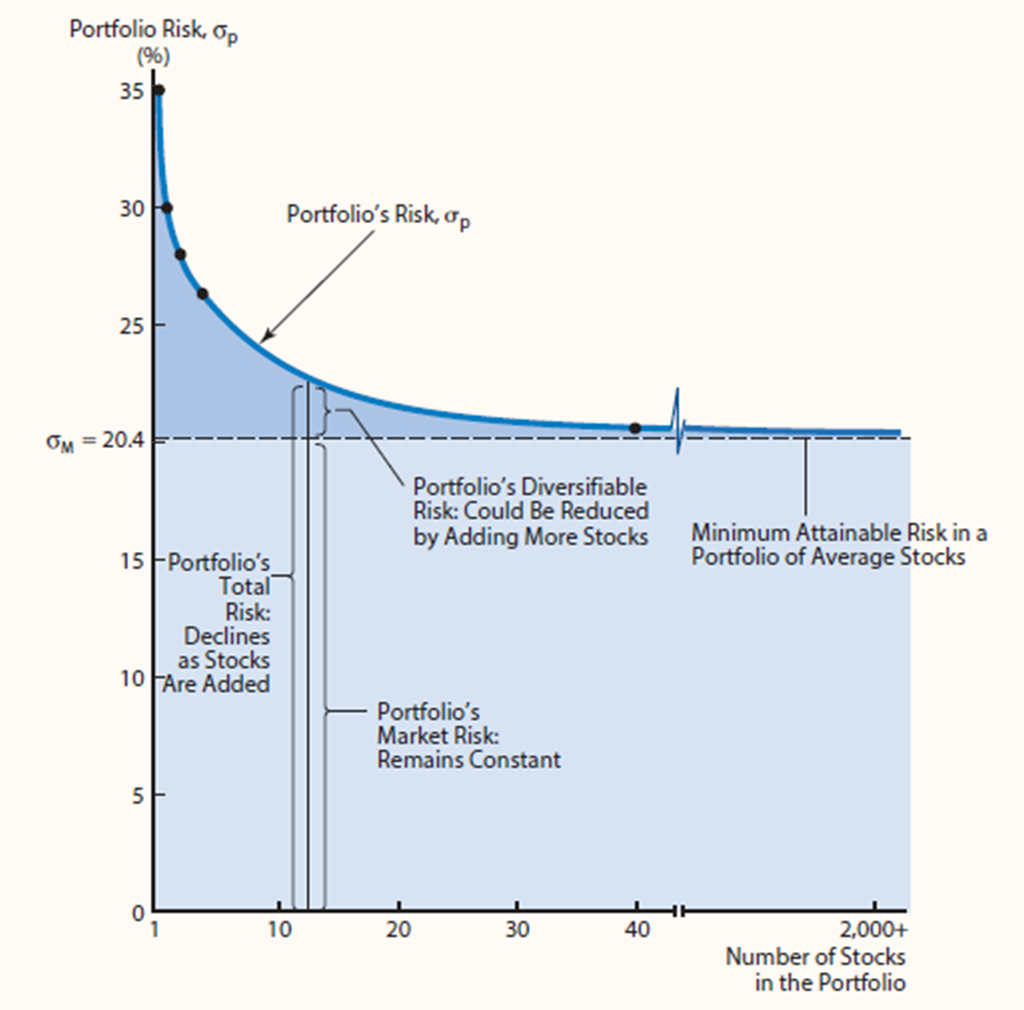

- σp decreases as stocks are added if they are not perfectly correlated with the existing portfolio.
- Expected return of the portfolio should remain relatively constant.
- Eventually the diversification benefits of adding more stocks dissipates (after about 40 stocks), and for large stock portfolios, σp tends to converge to ≈ 20%.

Chapter 8 topics

## CAPM

- Capital Asset Pricing Model
- Proposition
  - Any stocks required return is equal to the risk free rate plus a risk premium for the risks remaining after diversification (market risk, also called systematic risk)
- Beta
  - This is the main result from the model
  - How much does my stock move this the market return

Chapter 8 topics

## Beta

[figure not shown]

- $\beta$ or b as your book says is the relationship between the Market return and the return of a stock.
- Rise over Run
- Beta of 1 is average
- Beta of 2 is high
- Beta of -1?

Five years of returns on the market and on stocks H, A and L

| Year | r<sub>M</sub> | r<sub>H</sub> | r<sub>A</sub> | r<sub>L</sub> |
| --- | --- | --- | --- | --- |
| 1 | 10.0% | 10.0% | 10.0% | 10.0% |
| 2 | 20.0% | 30.0% | 20.0% | 15.0% |
| 3 | -10.0% | -30.0% | -10.0% | 0.0% |
| 4 | 0.0% | -10.0% | 0.0% | 5.0% |
| 5 | 5.0% | 0.0% | 5.0% | 7.5% |

Chapter 8 topics

## Portfolio Beta

Assume you have 1M dollars invested in a 1.2 beta portfolio. You will purchase 0.5M of a 2 beta stock.

What will happen to the portfolio beta?

- It will go up! A riskier stock as been added so the risk of the portfolio goes up

What will the new portfolio beta be?

$$b_p = w_1 b_1 + w_2 b_2 + ... + w_N b_N$$

$$b_p = \frac{1}{1.5} \ast 1.2 + \frac{0.5}{1.5} \ast 2 = 1.47$$

Chapter 8 topics

## Market Risk Premium

- The price of risk or the risk premium
  - This is the additional rate of return that is required to hold a risky asset over a less risky one
- Construct a market portfolio
  - The average return of that portfolio historically is 8%
- We use the risk-free rate as our less risky benchmark

$$r_{rf} = r^* + IP$$

- In practice we use a treasury bill as the risk free rate
  - I will ask questions using either rate
- Then our market risk premium is

$$RP_m = r_m - r_{rf}$$

- Note on notation: $\hat{r_i}$ is expected return; $r_i$ is required return

Chapter 8 topics

## SML

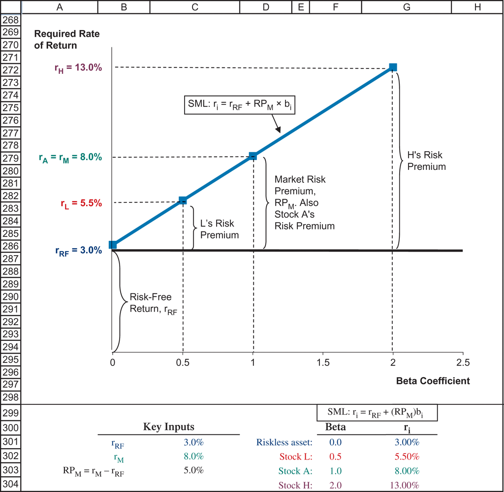

- $r_H$ has a beta of 2
- $r_A$ has a beta of 1
- $r_L$ has a beta of 0.5
- What would a zero beta stock earn?

$$\begin{array}{rl}
r_i &= r_{rf} + RP_m \ast b_i \\
RP_m &= 5\% \\
r_{rf} &= 3\%
\end{array}$$

Chapter 8 topics

## Example

Your stock has a beta of 1.2. The market risk premium is 5% and the risk free rate is 3%. What is the required rate of return on your stock?

$$r_i = r_{rf} + RP_m b_i$$

$$r_i = 3\% + 5\% \ast 1.2 = 9$$

What is the return on the market, $r_m$?

$$r_m = r_{rf} + RP_m$$

$$r_m = 3\% + 5\% = 8\%$$

Chapter 8 topics

## Required return from a T-bill rate

The risk free rate is in practice the same as a short term T-bill.

The T-bill rate is 3%, the market risk premium is 6% and the stock has a beta of 1.4.

What is the required rate of return?

$$r_i = r_{rf} + RP_m b_i$$

3% + 1.4 * 6% = 11.40%

Chapter 8 topics

## How does the SML change

- Inflation
  - If the inflation expectations increase, then investors need to be compensated for that. This will raise $r_{rf}$ AND therefore all required rates of returns!
  - Same as bonds
- Risk aversion
  - If investors become more risk averse, then they want more compensation for risk! This means that the risk premium goes up and the slope of the SML will change
  - Slope=RP of the market

Chapter 8 topics

## Risk and Return

Two stocks, with the risk free rate at 6% and a market premium of 5%

|  | Stock X | Stock Y |
| --- | --- | --- |
| Beta | 0.9 | 1.2 |
| Expected Return | 10% | 12.5% |
| SD | 35% | 25% |

- The RF is 6% and market premium is 5%
- What is the CV?
- Each required rate of return?
- You invest $7.5K in X and $2.5K in Y what the required return of the portfolio?
- If the market risk premium increased to 6% which stock has the largest increase in required return?

$$CV_x = \frac{\sigma_x}{\hat{r_x}} = \frac{35\%}{10\%} = 3.5$$

$$CV_y = \frac{\sigma_y}{\hat{r_y}} = \frac{25\%}{12.5\%} = 2$$

$$r_x = 6\% + 0.9 \ast 5\% = 10.5\%$$

$$r_y = 6\% + 1.2 \ast 5\% = 12\%$$

$$\beta_p = 0.9 \ast \frac{7500}{10000} + 1.2 \ast \frac{2500}{10000} = 0.975$$

$$r_p = 6\% + 0.975 \ast 5\% = 10.875\%$$

$$r_x = 6\% + 0.9 \ast 6\% = 11.4\%$$

$$r_y = 6\% + 1.2 \ast 6\% = 13.2\%$$

Chapter 8 topics

## Over and undervalued

- The CAPM tells you the return you should REQUIRE for the risk you are taking
- Work out the return you EXPECT from the price
- Compare the two

What does it mean if the two are not equal?

Expected above required: the price is too low. Undervalued, and you buy it.

Expected below required: the price is too high. Overvalued.

Chapter 8 topics

## Should you buy LMARK?

Shares of LMARK currently trade at $18.00. You expect the price to be $19.58 in one year (no dividends). The S&P 500 expected return is 11.00%, the T-bill rate is 3.00%, and LMARK has a beta of 1.1.

Should you buy this stock?

Expected: $(19.58 - 18.00)/18.00 = 8.78\%$ Required: $3\% + 1.1(11\% - 3\%) = 11.80\%$

**8.78% is below 11.80%, so LMARK is overvalued. Do not buy it.**

[figure not shown]

What would it have to trade at today for it to be correctly valued?

Hint(discount the expected price with the correct rate)

$19.58 / 1.118 = **$17.51**, so it is about 49 cents too expensive.

Chapter 8 topics

## CAPM and required return

You manage a $5M portfolio and a $\beta$ of 1.15 and a required rate of return of 11.475%. The current risk-free rate is 4%. Assume you receive another $500k. If you invest the money in a stock with a $\beta$ of 0.85, what will be the required return on your portfolio?

$$R_i = R_f + RP_m \ast \beta_p$$

- What is $RP_m$?

$$11.475 = 4 + RP_m \ast 1.15 \rightarrow RP_m = \frac{11.475 - 4}{1.15} = 6.5$$

- Portfolio Beta

$$\frac{5M \ast 1.15 + 0.5M \ast 0.85}{5.5} = \frac{6.175}{5.5} = 1.12$$

- Required Return

$$R_i = 4 + 6.5 \ast \frac{6.175}{5.5} = 11.30$$

Chapter 8 topics

## Practice: Required Rate of Return

- The risk free rate is 4%, that market return is 10%, and your stock’s $\beta$ is 1.4.
- What is the required rate of return on your stock?

$$r_i = r_{rf} + \beta \ast \left( r_m - r_{rf} \right)$$

$$r_i = 4 + \left( 10 - 4 \right) \ast 1.4 = 12.4\%$$

- The risk free rate increases to 5% and the slope of the SML is the same. What is the return on the market? On your stock?

If the slope is the same, then $\left( r_m - r_{rf} \right)_1 = \left( r_m - r_{rf} \right)_2$

so $r_m = r_{rf} + RP = 5 + 6 = 11$

$$r_i = 5 + \left( 11 - 5 \right) \ast 1.4 = 13.4\%$$

- The risk free is 4%, but the market return increases to 12% what is $r_i$?

$$r_i = 4 + \left( 12 - 4 \right) \ast 1.4 = 15.2\%$$

Chapter 8 topics

## Chapter 9: Stocks

All chapters

## Gordon Growth Model

- If I know the required rate of return, a dividend, and the growth rate of dividends, then I can find price

$$P_0 = \frac{D_1}{r_s - g} = \frac{D_0 \left( 1 + g \right)}{r_s - g}$$

- $r_s$ is the discount rate for the stock. We will use the CAPM to find it.

Chapter 9 topics

## Example

There is a stock with a $r_s$ of 9% and a $g$ of 3%. The next dividend paid will be $4.12. Find the price of the stock

$$P_0 = \frac{D_1}{r_s - g} = \frac{\$4.12}{9\% - 3\%} = \$68.67$$

- $P_0$ = A stock’s estimated intrinsic value now
- D0 = Current Dividend
- D1 = Next year’s dividend
- rs = The required rate of return
- g = dividend growth rate

Chapter 9 topics

## Stock Price

- Assumptions:
  - $r_{RF}$=Risk Free Rate=3%
  - $r_M$=Market Return=7%, therefore Market Risk Premium=4%
  - Springfield Nuclear Energy’s Beta (β)=1.5 (given)
  - D0=Current Dividend is $3.00 per share
  - Dividend growth rate (g) is constant 5%
- Find the estimated intrinsic value of the stock, $P_0$

Chapter 9 topics

## Answer: Stock Price

- Assumptions:
  - $r_{RF}$=Risk Free Rate=3%
  - $r_M$=Market Return=7%, therefore Market Risk Premium=4%
  - Springfield Nuclear Energy’s Beta (β)=1.5 (given)
  - D0=Current Dividend is $3.00 per share
  - Dividend growth rate (g) is constant 5%
- Find the estimated intrinsic value of the stock, $P_0$
- Step 1 Estimate required rate of return rs = rRF + (rM – rRF)β = 3% + (7%-3%)*1.5 = 9%
- Step 2 Estimate next year’s dividend which equals D1 = D0(1 + g)1 = $3.00(1+5%) = $3.15
- Step 3 Estimate current stock price which equals $P_0$ = $\frac{D_1}{r_s - g}$ = $\frac{\$3.15}{9\% - 5\%}$ = $78.75

Chapter 9 topics

## Acme Stock Price

- Assumptions:
  - Risk Free Rate=4%
  - Market Return=9%, therefore Market Risk Premium=5%
  - Acme Metals Beta=1.15 (given)
  - Current Dividend is $4.00 per share
  - Constant growth rate is 4%
- Find the stock’s intrinsic value

Chapter 9 topics

## Answer: Acme Stock Price

- Assumptions:
  - Risk Free Rate=4%
  - Market Return=9%, therefore Market Risk Premium=5%
  - Acme Metals Beta=1.15 (given)
  - Current Dividend is $4.00 per share
  - Constant growth rate is 4%
- Find the stock’s intrinsic value
- Step 1, Find required rate of return = rs = 4% +1.15*(9%-4%) = 9.75%
- Step 2, Find $D_1$ = $4.00 *(1 + 4%) = $4.16
- Step 3, Find estimated intrinsic value = $P_0 = \frac{D_1}{r_s - g}$ = $\frac{\$4.16}{9.75\% - 4\%}$ = $72.35

Chapter 9 topics

## Chapter 10: Cost of Capital

All chapters

## YTM

Outstanding bond issue, 15-year, 12% coupon, semiannual payment noncallable bonds sell for $1,153.72.

YTM?

N30I/Y?PV-1,153.72PMT60FV1000

CPT I/Y5%

Nominal Rate=Periodic Rate*2=10%

Chapter 10 topics

## Is this the cost of my debt?

- 10% is what I would have to pay to go out and borrow
- But what is extra special about interest expense?
  - Tax deductible!
  - We pay interest then calculate tax liability
- So if we have a tax rate of 25% and our YTM is 10% what is the actual cost we pay?

r<sub>d</sub>(1 − T) = 10% × (1 − 25%) = 7.5%

Chapter 10 topics

## DDM Method

- Common stock sells for $50. D0=$4.19 and g=5%.
- DCF Model is

$$r_s = \frac{D_1}{P_0} + g$$

Two steps of the dividend discount method, worked

| Step | Result |
| --- | --- |
| Step 1, insert numbers | $r_{s} = \frac{\$ 4.19(1 + .05)}{\$ 50} + .05$ |
| Step 2, solve | rs=8.80%+5%=13.80% |

Chapter 10 topics

## New Equity Costs

- Assuming a 15% flotation cost, find the cost of equity associated with issuing new common stock.
- D0=$4.19, g=5% and the current stock price is $50, F=flotation costs of 15%

$$r_e = \frac{D_0 \left( 1 + g \right)}{P_0 \left( 1 - F \right)} + g$$

$$\begin{aligned} r_e &= \dfrac{\$4.19 \left( 1.05 \right)}{\$50 \left( 1 - 0.15 \right)} + 5.0\% \\ &= \dfrac{\$4.3995}{\$42.50} + 5.0\% \\ &= 15.4\% \end{aligned}$$

Chapter 10 topics

## Finding the WACC

$$WACC = w_d r_d \left( 1 - T \right) + w_p r_p + w_c r_s$$

The weights come from the Target column

|  | Book Value | Market Value | Target |
| --- | --- | --- | --- |
| Debt (includes notes payable) | 48% | 25% | 30% |
| Preferred stock | 2% | 5% | 10% |
| Common equity | 50% | 70% | 60% |

- The tax rate is 25%
- rd=10.6, rp=10.8.
- The cost of equity from the CAPM was 13.5, from the DDM it was 14.3, and the bond yield method was 15.88. You trust them equally.

r<sub>s</sub> = (13.5 + 14.3 + 15.88) / 3 = 14.56

WACC = 0.3 × 10.6 × (1 − 25%) + 0.1 × 10.8 + 0.6 × 14.56 = 12.2

Chapter 10 topics

## Chapter 11: Capital Budgeting

All chapters

## Cupcake Expansion

- Taylor’s Cupcakes is planning an expansion.
- Initial cost for new food trailer- $7000

Taylor's Cupcakes expansion cash flows by year

| Year 1 - $3000 | Year 2 - $5000 | Year 3 - $5000 |
| --- | --- | --- |
| Year 4 - $5000 | Year 5 - $5000 | Year 6 - $4000 |

- Find the NPV if her discount rate is 10 percent. Then find the IRR

NPV -> I=10 -> NPV=12,393.65

IRR=55.63

Chapter 11 topics

## Cupcake Expansion

The same expansion as it goes into the CF worksheet

| Key | Entry |
| --- | --- |
| Cfo | -7000 |
| C01 | 3000 |
| F01 | 1 |
| C02 | 5000 |
| F02 | 4 |
| C03 | 4000 |
| F03 | 1 |

NPV -> I=10 -> NPV=12,393.65

IRR=55.63

Would the NPV positive with a rate of 58%?

Chapter 11 topics

## Interpreting the IRR

- If IRR > WACC, you can conclude that present value of a project’s cash inflows exceeds the present value of its outflows.
- If IRR > WACC, accept project.
- If IRR < WACC, reject project.

Chapter 11 topics

## Payback period

- The number of years required to recover a project’s cost
- Calculated by adding a project’s cash inflows to its cost until the cumulative cash flow for the project turns positive.
- Strengths
  - Provides an indication of a project’s risk and liquidity.
  - Easy to calculate and understand.
- Weaknesses
  - Ignores the time value of money (TVM).
  - Ignores CFs occurring after the payback period.
  - No relationship between a given payback and shareholder wealth maximization.

Chapter 11 topics

## Payback and Discounted Payback

$$\begin{aligned} Payback = {} & \text{Number of years prior to full recovery} \\ & + \frac{\text{Unrecovered cost at start of year}}{\text{Cash flow during full recovery year}} \end{aligned}$$

- Project Payback Calculation

Project L’s cash flows

|  | 0 | 1 | 2 | 3 |
| --- | --- | --- | --- | --- |
| CF<sub>t</sub> | -100 | 10 | 60 | 80 |

Project L’s cumulative cash flow

|  | 0 | 1 | 2 | 3 |
| --- | --- | --- | --- | --- |
| Cumulative | -100 | -90 | -30 | 50 |

$$Payback_L = 2 + \frac{30}{80} = 2.375 \text{ years}$$

- Discounted Payback: Uses discounted cash flows rather than nominal CFs.

Project L’s cash flows at 10%

| 10% | 0 | 1 | 2 | 3 |
| --- | --- | --- | --- | --- |
| CF<sub>t</sub> | -100 | 10 | 60 | 80 |

Project L’s discounted cumulative cash flow

|  | 0 | 1 | 2 | 3 |
| --- | --- | --- | --- | --- |
| PV of CF<sub>t</sub> | -100 | 9.09 | 49.59 | 60.11 |
| Cumulative | -100 | -90.91 | -41.32 | 18.79 |

$$Disc\ Payback_L = 2 + \frac{41.32}{60.11} = 2.7 \text{ years}$$

Chapter 11 topics

## Can we save IRR

- One of the issues is that we assume that CFs will earn the IRR!
- We can change that!
- We will modify it to be MIRR

Chapter 11 topics

## MIRR

- Assume that cash-flows can earn some rate, WACC.
- Then what is the discount rate that your CF0 would have to earn to get that FV

$$PV\ Costs = \frac{TV}{\left( 1 + MIRR \right)^N}$$

$$\sum \frac{COF_t}{\left( 1 + r \right)^t} = \frac{\sum CIF_t \left( 1 + r \right)^{N-t}}{\left( 1 + MIRR \right)^N}$$

- Get the PV of the outflows and the FV of the inflows. The rate that sets them equal is the MIRR

Chapter 11 topics

## First Simple Example

- Assume CFs are as follows: CF0: -100, CF1: 100, CF2: 100 and the WACC is 10% find the MIRR.

$$\sum \frac{COF_t}{\left( 1 + r \right)^t} = \frac{\sum CIF_t \left( 1 + r \right)^{N-t}}{\left( 1 + MIRR \right)^N}$$

- First, we need the PV of our costs
- All negative signs, -100
- That is PV of our costs
- Now FV of each of our positive Numbers
- FV(CF2) is 100
- FV(CF1) is 100(1+10%)=110
- 210

Chapter 11 topics

## First Simple Example Cont.

- Assume CFs are as follows: CF0: -100, CF1: 100, CF2: 100 and the WACC is 10% find the MIRR.

$$100 = \frac{210}{\left( 1 + MIRR \right)^2}$$

- Solve for rate with PV of -100, FV of 210 and 2 time periods

N2I/Y?PV-100PMT0FV210

CPT I/Y44.91%

What would change if the CF at time 1 was negative?

Chapter 11 topics

## Cupcake Wars

- In their continuing war to be the top cupcake producer in Northern Mississippi, Taylor’s Cupcakes is planning their largest expansion yet to Olive Branch. It will cost 275K initially. The CF for the following 5 years are 87,000, 99,000, 69,000, 61,000, and 92,800. The WACC is 10%
- Step 1: Find the PV of all the inflows (positive numbers)
  - Enter all CF to the register except Cfo. Find NPV

$312,035.13

- Now get FV of that $312K
  - -312035.13 into PV, 5 into [N], and 10 into [I/YR]

N5I/Y10PV-312,035.13PMT0FV?

CPT FV$502,535.70

- Now we need the rate that sets 275K initial investment equal to 502K
  - -275,000 into PV and then [CPT] [I/YR]

N5I/Y?PV-275,000PMT0FV502,535.70

CPT I/Y12.81%

Chapter 11 topics

## Crossover Rate

- The crossover rate is the WACC (discount rate or rate of return) that equates the net present value of two mutually exclusive capital projects
- It is the rate at which one mutually exclusive project becomes more attractive than the other as measured by NPV
- Different decisions are made about which mutually exclusive project to accept at discount rates (or Weighted Average Costs of Capital) that are above or below the crossover rate

Chapter 11 topics

## Crossover Rate

The IRR of the difference IS the crossover rate

| YEAR | A | B | ΔCF |
| --- | --- | --- | --- |
| 0 | -100 | -100 | 0 |
| 1 | 10 | 70 | -60 |
| 2 | 60 | 50 | 10 |
| 3 | 80 | 20 | 60 |

8.68%

- ΔCF is the differences between the projects’ cash flows.
- Use IRR function to calculate IRR of ΔCF cash flows.
- The IRR of ΔCF is the crossover rate.
- IRR of ΔCF cash flows=Crossover rate=8.68%.
- Project B’s Net Present Value is higher than A’s if the WACC > 8.68%
- Project A’s Net Present Value is higher than B’s if the WACC<8.68%
- If a crossover rate does not exist, one project has a higher NPV than the other at all costs of capital

Chapter 11 topics

## Practice at home: NPV

- A project pays $5k per year for 10 years and then $9k per year for the following ten years. The 20 year IRR is 8.52% and the WACC is 8%. What is the NPV?
- First, what are we missing for NPV?
- How can IRR help?
- Use the cash flow register
  - 0 for CF0, 5k for 10 years, 9K for another 10 years.
  - Then use 8.52% for I and get NPV

58,824.11

- Go back and update CF register and use WACC for I.

NPV=2,698.89

Chapter 11 topics

## Chapter 12: Cash Flow Estimation

All chapters

## Incremental Cash Flows

- IMPORTANT
- Ask yourself this question:
  - Would the cash flow still exist if the project does not exist?
    - If yes, do not include it in your analysis.
    - If no, include it.

Chapter 12 topics

## Sunk Costs

- Costs that occur in the past and cannot be recovered.
- We should not include these! We only want to know if there will be future
- Suppose Justin’s Cupcakes is planning a future expansion. We spend 2 million to investigate if we should under take it.
- We find that we need an additional 17M investment to open the store.
- NPV with 19M investment (including 2M site study) is -1M
- NPV with 17M investment is 1M
- Which is correct?

Chapter 12 topics

## Issues with Estimating Cash Flows

- Sunk costs=exclude. Ask yourself if rejecting the project affects this cost.
- Financing costs, such as interest expense=EXCLUDE. Already included in WACC.
- Opportunity Costs=INCLUDE. Generally revenues forgone from using land or building for another purpose other than the project
- Externalities=effects of a project on cash flows in other part of the firm. Can be positive or negative and should be INCLUDED as part of the project’s incremental cash flows.
- Cannibalization=INCLUDE. A negative externality, occurs when the introduction of a new product diminishes the sales of existing products.

Chapter 12 topics

## Extra Practice: New Project Analysis

- Your company wants to buy a spectrometer for $170K. The equipment will be fully depreciated at purchase and would be sold after 3yr for $60K. The equipment would require an increase of $8K NOWC for spare parts. Assume that can be fully recovered when sold. The project would have no effect on revenue but would save the firm $50K in before tax labor costs. The firms marginal tax rate is 25%.
- What is the Year 0 cash flow?

$$\text{Project Free Cash Flows} = EBIT \left( 1 - T \right) + DEP - CAPEX - \Delta NOWC$$

$$\text{Project Free Cash Flows} = \left( Rev - Costs - Dep \right) \left( 1 - T \right) + DEP - CAPEX - \Delta NOWC$$

$$FCF = -170K \left( 1 - 25\% \right) + 170K - 170K - 8K = -170K \ast 75\% - 8K$$

$$= -\$135.5K$$

Chapter 12 topics

## Extra Practice: New Project Analysis

- Your company wants to buy a spectrometer for $170K. The equipment will be fully depreciated at purchase and would be sold after 3yr for $60K. The equipment would require an increase of $8K NOWC for spare parts. Assume that can be fully recovered when sold. The project would have no effect on revenue but would save the firm $50K in before tax labor costs. The firms marginal tax rate is 25%.
- What is the Years 1 and 2 cash flow?

$$\text{Project Free Cash Flows} = EBIT \left( 1 - T \right) + DEP - CAPEX - \Delta NOWC$$

$$\text{Project Free Cash Flows} = \left( Rev - Costs - Dep \right) \left( 1 - T \right) + DEP - CAPEX - \Delta NOWC$$

$$FCF = 50K \left( 75\% \right) + 0 - 0 - 0 = \$37.5K$$

Chapter 12 topics

## Extra Practice: New Project Analysis

- Your company wants to buy a spectrometer for $170K. The equipment will be fully depreciated at purchase and would be sold after 3yr for $60K. The equipment would require an increase of $8K NOWC for spare parts. Assume that can be fully recovered when sold. The project would have no effect on revenue but would save the firm $50K in before tax labor costs. The firms marginal tax rate is 25%.
- What is the Year 3 cash flow?

$$\text{Project Free Cash Flows} = EBIT \left( 1 - T \right) + DEP - CAPEX - \Delta NOWC$$

$$\text{Project Free Cash Flows} = \left( Rev - Costs - Dep \right) \left( 1 - T \right) + DEP - CAPEX - \Delta NOWC$$

$$FCF = 50K \left( 75\% \right) + 0 - \left( -60K \left( 75\% \right) \right) - 0 - \left( -8K \right) = \$90.5K$$

Chapter 12 topics

## Extra Practice: New Project Analysis

- Your company wants to buy a spectrometer for $170K. The equipment will be fully depreciated at purchase and would be sold after 3yr for $60K. The equipment would require an increase of $8K NOWC for spare parts. Assume that can be fully recovered when sold. The project would have no effect on revenue but would save the firm $50K in before tax labor costs. The firms marginal tax rate is 25%.
- What is the NPV of the project? WACC is 10%

$$NPV = -135.5K + \frac{37.5K}{1 + 10\%} + \frac{37.5K}{\left( 1 + 10\% \right)^2} + \frac{90.5K}{\left( 1 + 10\% \right)^3} = -2.4K$$

The four cash flows, in thousands

| Y0 | -135.5 |
| --- | --- |
| Y1 | 37.5 |
| Y2 | 37.5 |
| Y3 | 90.5 |

Chapter 12 topics

## Unequal Lives

- You are replacing your fully depreciated machine. Model 120-2 has an after-tax cost of $120K, 2yr expected life and after-tax cash flow of $80K per year. Model 250-3 has a after tax cost of $250K, 3yr life and after-tax cash flows of $113K per year. Both projects can be repeated and costs of machines are not expected to rise. Assume your WACC is 13%
- Use the replacement chain approach and determine which to buy

[figure not shown]

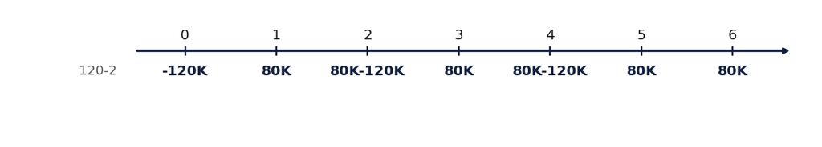

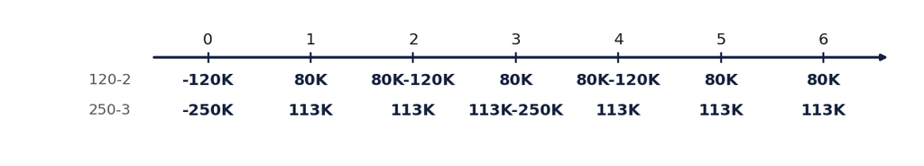

NPV: 32.23

NPV: 28.46

Chapter 12 topics

## Unequal Lives

- You are replacing your fully depreciated machine. Model 120-2 has an after-tax cost of $120K, 2yr expected life and after-tax cash flow of $80K per year. Model 250-3 has a after tax cost of $250K, 3yr life and after-tax cash flows of $113K per year. Both projects can be repeated and costs of machines are not expected to rise. Assume your WACC is 13%
- Use the EAA

[figure not shown]

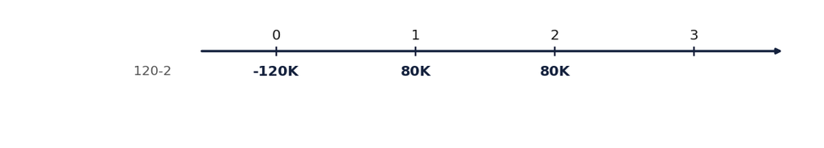

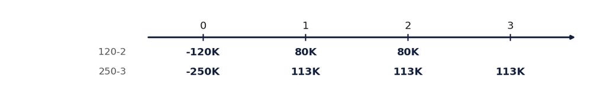

NPV: 13.45K

NPV: 16.81K

EAA<sub>120-2</sub>=8.06K

EAA<sub>250-3</sub>=7.12K

N2I/Y13PV-13.45PMT?FV0

CPT PMT8.06

N3I/Y13PV-16.81PMT?FV0

CPT PMT7.12

Chapter 12 topics

## Upcoming Dates

Upcoming class dates and deadlines

| Date | Topic | Due / Notes |
| --- | --- | --- |
| Tue Nov 24 | Thanksgiving holidays - no class | - |
| Thu Nov 26 | Thanksgiving holidays - no class | - |
| Tue Dec 1 | Review for Final | Review |
| Thu Dec 3 | Review for Final | Review |

**Office:** 325 Holman Hall · **Office hours:** T TH 10:50A-12:20P · jjmohr1@olemiss.edu